# Lesson 19: Inference for Several Proportions, Goodness-of-Fit, and Independence

Homework

- Word Document
- PDF Document

###L19: Homework Assignment

**Instructions: You are encouraged to collaborate with other students on the homework, but it is important that you do your own work. Before working with someone else on the assignment, you should attempt each problem on your own.**

*In the last month, how often have you been angered because of something that happened outside of your control?*

| Anger Frequency | High | Medium | Low |
| --- | --- | --- | --- |
| Never | 214 | 129 | 60 |
| Sometimes | 145 | 61 | 55 |
| Often | 29 | 18 | 27 |

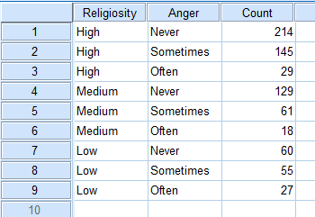

ReligiosityTableSPSS

Use this information to answer questions 1 through 7.

1. Verify that the requirements are satisfied to conduct a $\chi^2$ test for independence.
2. Create a clustered bar to illustrate this data.
3. State the appropriate null and alternative hypotheses.
4. Calculate the test statistic and give its degrees of freedom ($df$).
5. Calculate the P-value based on the test statistic.
6. What decision do you make based on the P-value and the level of significance ($\alpha$)?
7. State your conclusion in an English sentence.

A sociologist wanted to discover whether family structure and whether or not girls attend college are related. She randomly selected 380 18-year-old female students about to graduate from high school and asked each to disclose her family structure and if she was planning on attending college. Use the data below to determine if there is a connection between family structure and whether or not girls attend college. Use a level of significance of $\alpha = 0.05$.

|  | Both Parents | Single Parent | Parent and Step Parent | Nonparental Guardian |
| --- | --- | --- | --- | --- |
| **Going to College** | 86 | 41 | 36 | 18 |
| **Not Going to College** | 64 | 59 | 44 | 32 |

Use this information to answer questions 8 through 14.

8. Verify that the requirements are satisfied to conduct a $\chi^2$ test for independence.
9. Create a clustered bar to illustrate this data.
10. State the appropriate null and alternative hypotheses.
11. Calculate the test statistic and give its degrees of freedom ($df$).
12. Calculate the P-value based on the test statistic.
13. What decision do you make based on the P-value and the level of significance ($\alpha$)?
14. State your conclusion in an English sentence.

| Status | Men | Women |
| --- | --- | --- |
| Completed | 423 | 156 |
| Still Enrolled | 134 | 63 |
| Dropped | 238 | 98 |

Use this information to answer questions 15 through 21.

15. Verify that the requirements are satisfied to conduct a $\chi^2$ test for independence.
16. Create a clustered bar to illustrate this data.
17. State the appropriate null and alternative hypotheses.
18. Calculate the test statistic and give its degrees of freedom ($df$).
19. Calculate the P-value based on the test statistic.
20. What decision do you make based on the P-value and the level of significance ($\alpha$)?
21. State your conclusion in an English sentence.